# Prosper Loan Analysis

Now lets go deeper with Debt to Income and see if we can find anything

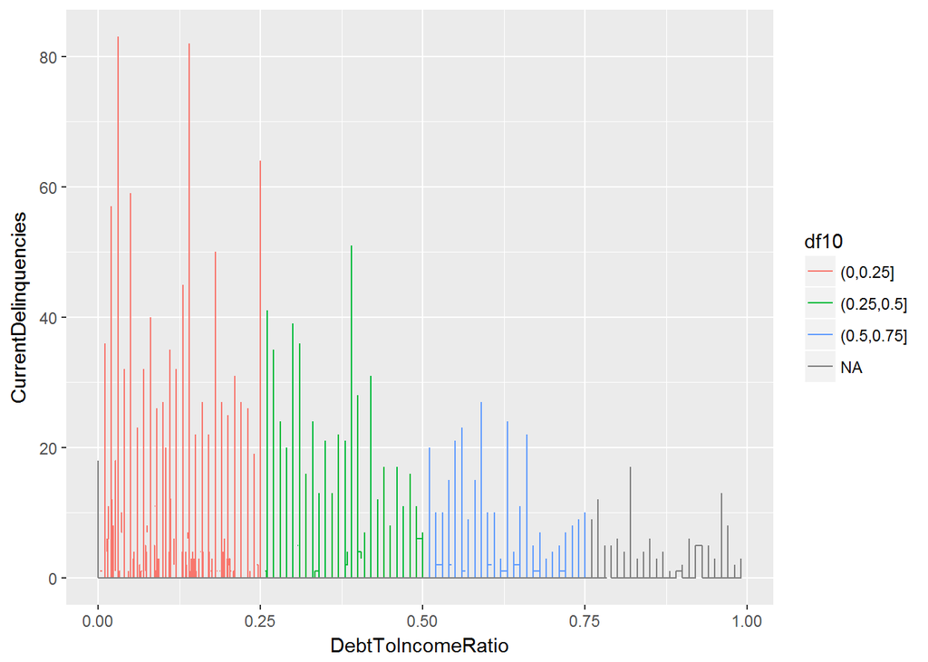

There seems to be a clear trend here as well. As Debt to Income ratio increases the number of delinquencies does decrease

Here we look at the population size of debt to income ratios to see if can find any trends.

```
## # A tibble: 1 x 1
##       n
##   <int>
## 1 61086
```

```
## # A tibble: 1 x 1
##       n
##   <int>
## 1 35713
```

```
## # A tibble: 1 x 1
##       n
##   <int>
## 1  3841
```

```
## # A tibble: 1 x 1
##       n
##   <int>
## 1  1372
```

This is the graph for income to debt rations above 1. Surprisingly the graph is fairly uniform.

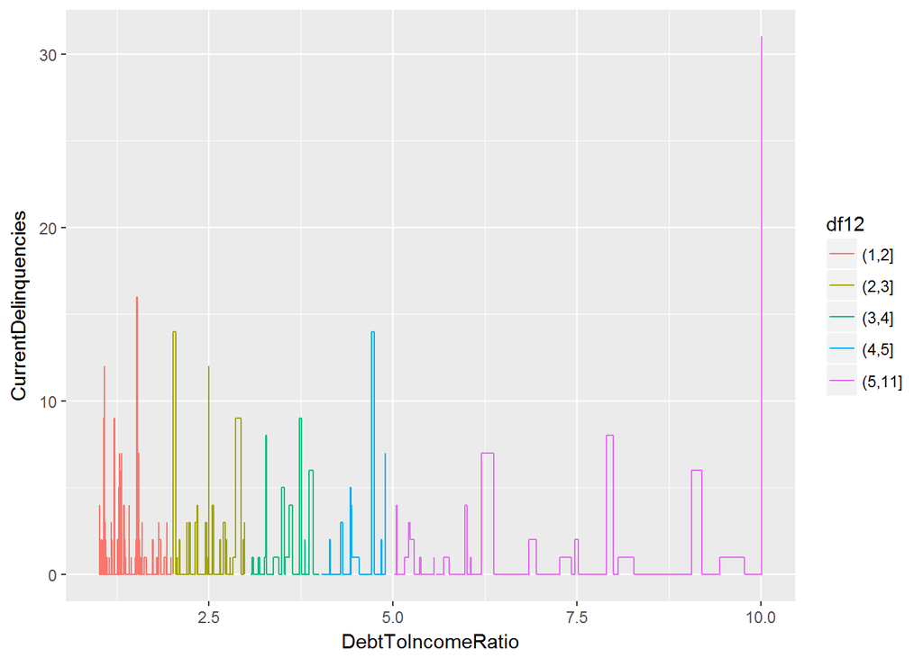